# Introduction

Ross, M. and Pawley, A. and Osmond, M.

## 1. Aims

This is the fifth in a series of volumes on the lexicon of the Proto Oceanic (POc) language.[^1] POc was the immediate ancestor of the Oceanic subgroup of the Austronesian language family. This subgroup consists of all the Austronesian languages of Melanesia east of 136˚ E, together with those of Polynesia and (with two exceptions) those of Micronesia — more than 450 languages in all (see Map 1).[^2] Extensive arguments for the existence of Oceanic as a clearly demarcated branch of Austronesian were first put forward by Otto Dempwolff in the 1920s, and the validity of the subgroup is now recognised by virtually all scholars working in Austronesian historical linguistics.

The development and break-up of the POc language and speech community were stages in a truly remarkable chapter in human prehistory—the colonisation by Austronesian speakers of the Indo-Pacific region in the period after about 2000 BC. The outcome was the largest of the world’s well-established language families and (until the expansion of Indo-European after Columbus) the most widespread. The Austronesian family comprises more than 1,000 distinct languages. Its eastern and western outliers, Madagascar and Easter Island, are two-thirds of a world apart, and its northernmost extensions, Hawai’i and Taiwan, are separated by 70 degrees of latitude from its southernmost outpost, Stewart Island in New Zealand.

It is likely that the divergence of Oceanic from its nearest relatives, which are the Austronesian languages spoken around Cenderawasih Bay and in South Halmahera (Blust 1978a), began when Austronesian speakers from the Cenderawasih Bay area moved eastwards along the north coast of New Guinea and into the Bismarck Archipelago. There is a strong school of opinion that associates the subsequent break-up of POc with the rapid colonisation of Island Melanesia and the central Pacific by bearers of the Lapita culture between about 1200 and 900 BC (see Map 2 and volume 2, chapter 2).

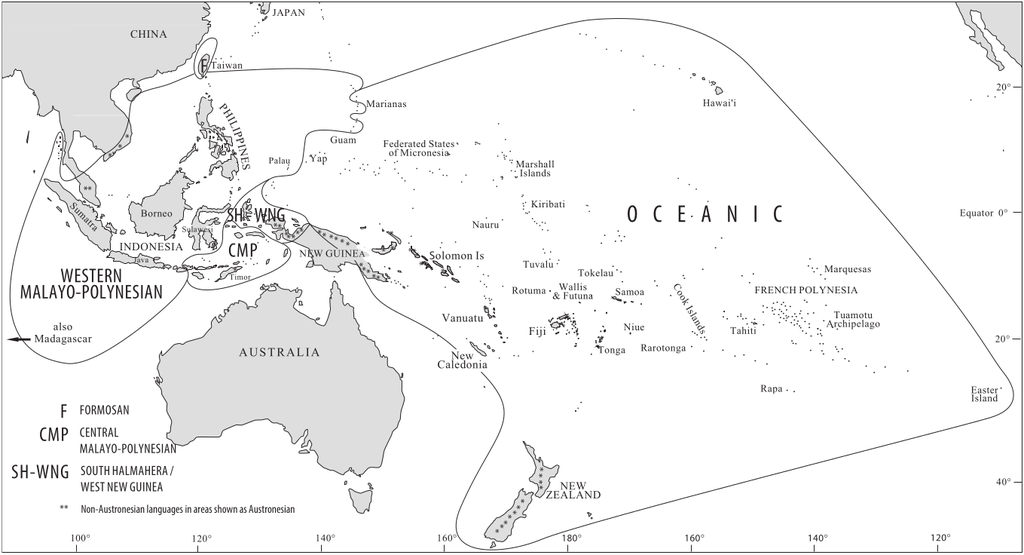

**Map 1:** The Austronesian language family and major subgroups

The present project aims to bring together a large corpus of lexical reconstructions for POc, with supporting cognate sets, organised according to semantic fields and using a standard orthography for POc. We hope that it will be a useful resource for culture historians, archaeologists and others interested in the prehistory of the Pacific region. The comparative lexical material should also be a rich source of data for various kinds of purely linguistic research, e.g. on semantic change and subgrouping in the more than 450 daughter languages.

Volume 1 of *The lexicon of Proto Oceanic* deals with material culture. Volumes 2, 3 and 4 examine relevant sets of cognate terms in order to gain insights into how POc speakers viewed their environment. Volume 2 deals with the geophysical or inanimate environment, volumes 3 and 4 treat plants and animals respectively. The present volume and volume 6 return to terminologies centring on people. This volume is concerned with gender and age, the body, and human conditions and physical and cognitive activities that arise from nature rather than nurture. Volume 6 will concern culturally learned activities, social organisation, belief systems, rituals, recreation and other elements of non-material culture. The seventh and final volume will perform a number of functions. It will treat certain lexical categories, e.g. closed classes of lexical roots, not dealt with in earlier volumes. It will review the main findings of the project concerning the culture and environment of Proto Oceanic speakers and will compare these findings with what archaeology tells us about the way of life and environment of the bearers of the Lapita culture. Volume 7 will also provide an index to the POc and other reconstructions presented in the whole work, as well as an English-to-POc finderlist and a list of all languages cited, together with their subgroups.[^3]

Chapter 2 of the present volume presents reconstructions and supporting cognate sets for terms for people: ‘person’, ‘woman’, ‘man’, age cohort terms from early childhood to old age, terms for people by absence or deprivation of relationship (‘orphan’, ‘unmarried adult’, ‘widow(er)’) and for twins. Kin relationship terms are handled in volume 6 rather than here, as they are a dimension of social organisation.

Chapters 3 to 7 concern terms that have to do with the human body. Chapter 3 presents terms for the parts of the body and bodily substances, both substances of which the body is made up and which it emits. Chapter 4 is dedicated to conditions and activities of the human body, ranging from processes that occur spontaneously (sweating, breathing, snoring) to deliberate activities like eating, drinking and copulating. In between these extremes are numerous events with lesser degrees of agentivity, like sleeping, belching, yawning, defecating, laughing and crying. Chapter 5 is entitled ‘Health and disease’ and gives some insight into the diseases recognised and labelled by POc speakers. Chapter 6 investigates how Oceanic languages talk about posture and movement, the latter including not only human locomotion but also how people cause other people and things to move: raising and lowering, pulling, pushing and putting, various modes of carrying, and so on. Chapter 7 gives terms for a miscellany of activities performed with the body and its parts: working, gesturing, seizing and holding, treading, bathing and washing, waiting and hiding.

Chapters 8 to 11 deal with various aspects of the human mind. Chapter 8 presents terms for the five senses: seeing, hearing, smelling, tasting and perceiving by touch. Chapter 9 investigates the structure and semantics of body-part metaphors in Oceanic languages, as these evidently formed an integral part of the POc terminologies handled in Chapters 10 and 11. Chapter 10 examines terms for various aspects of cognition (knowing and thinking, truth, memory, deciding, agreeing, choosing and learning) and their organisation in POc. The final chapter, Chapter 11, presents terms that human beings use to describe one another with respect to their physical qualities, temperaments, emotions, desires and evaluations.

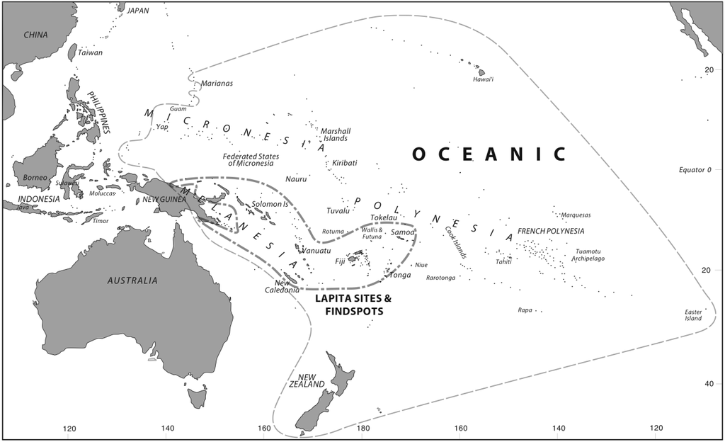

**Map 2:** Geographic limits of historically known Oceanic speakers and of presently documented Lapita sites (after Kirch_1997: 17, 54 and David et al._2011)

## 2. The relation of the current project to previous work

Reconstructions of POc phonology and lexicon began with Dempwolff’s pioneering work in the 1920s and 1930s. Dempwolff’s dictionary of reconstructions attributed to Proto Austronesian (PAn) (Dempwolff 1938)—but equivalent in modern terms to Proto Malayo-Polynesian (PMP)—contains some 600 reconstructions with reflexes in Oceanic languages.

Since the 1950s, POc and other early Oceanic interstage languages have been the subject of a considerable body of research. However, relatively few new reconstructions safely attributable to POc were added to Dempwolff’s material until the 1970s. In 1969 George Grace made available as a working paper a compilation of reconstructions from various sources amounting to some 700 distinct items, attributed either to POc or to early Oceanic interstages. These materials were presented in a new orthography for POc, based largely on Biggs’ (1965) orthography for an interstage he called Proto Eastern Oceanic. Updated compilations of Oceanic cognate sets were produced at the University of Hawai’i in the period 1977–1983 as part of a project directed by Grace and Pawley. These compilations and the supporting data are problematic in various respects and we have made only limited use of them.

Comparative lexical studies have been carried out for several lower-order subgroups of Oceanic: for Proto Polynesian by Biggs (resulting in Walsh & Biggs 1966, Biggs et al. 1970 and subsequent versions of the POLLEX file, including Biggs & Clark 1993, Clark & Biggs 2006 and Greenhill & Clark 2011); for Proto Micronesian by scholars associated with the University of Hawai’i (Bender et al. 1983, 2003); for the ancestor of the Banks and Torres languages by Alexandre François (several unpublished manuscripts); for Proto North and Central Vanuatu by Clark (Clark 1996, 2009); for Proto Southern Vanuatu by Lynch (1978b, 1996b, 2001c); for New Caledonia by Ozanne-Rivierre (1992), Haudricourt & Ozanne-Rivierre (1982) and Geraghty (1989); for Proto SE Solomonic by Levy (1980) and Lichtenberk (1988); for Proto Central Pacific by Hockett (1976), Geraghty (1983, 1986, 1996, together with a number of unpublished papers); for Proto Eastern Oceanic by Biggs (1965), Cashmore (1969), Levy and Smith (1970), and Geraghty (1990); and for Proto Central Papuan by Pawley (1975), Lynch (1978a, 1980), and Ross (1994a).

Robert Blust (1970, 1980b, 1983-84a, 1986, 1989) of the University of Hawai’i has, in a series of papers published extensive, alphabetically ordered, lexical reconstructions (with supporting cognate sets) for interstages earlier than POc, especially for Proto Austronesian, Proto Malayo-Polynesian and Proto Eastern Malayo-Polynesian. He has also written several papers investigating specific semantic fields (Blust 1980a, 1982b, 1987, 1994). Blust & Trussel have a major work in progress, the Austronesian Comparative Dictionary (ACD), which will bring together all Blust’s reconstructions for Proto Austronesian and lower-order stages. This is stored in electronic form at the University of Hawai’i.[^4] The version to which we refer dates from 2012.

Several papers predating our project systematically investigated particular semantic domains in the lexicon of POc, e.g. Milke (1958), French-Wright (1983), Pawley (1982a, 1985), Pawley & Green (1984), Lichtenberk (1986), Walter (1989), and the various papers in Pawley & Ross (1994). Ross (1988) contains a substantial number of new POc lexical reconstructions, as well as proposed modifications to the reconstructed POc sound system and the orthography. However, previous Oceanic lexical studies were limited both by large gaps in the data, with a distinct bias in favour of ‘Eastern Oceanic’ languages, and by the technical problems of collating large quantities of data. Although most languages in Melanesia remain poorly described, there are now many more dictionaries and extended word lists, particularly for Papua New Guinea, than there were in the 1980s. And developments in computing hardware and software now permit much faster and more precise handling of data than was possible then. A list of sources and a summary of the Project’s collation procedures is found in Appendix 1.

Several compilations of reconstructions have provided valuable points of reference, both inside and outside the Oceanic group. We are indebted particularly to Bender et al. (2003), two editions of POLLEX (Biggs & Clark 1993 and Clark & Biggs 2006), Blust & Trussel (ACD), Clark (2009) and Lynch (2001c).

In the course of planning the several volumes of the present project, we came to realise that the form in which preliminary publications were presented—namely as essays, each discussing cognate sets for a particular semantic field at some length—would also be the best form for the presentation of this set of volumes. A discursive treatment of individual terminologies, as opposed, say, to a dictionary-type listing of reconstructions with supporting cognate sets, makes it easier to relate the linguistic comparisons to relevant issues of culture history, language change, and methodology. Hence each of the present volumes has as its core a collection of analytic essays. Some of these have been published or presented elsewhere, but are included here in revised form. In some cases we have updated the earlier versions in the light of subsequent research, and, where appropriate, have inserted cross-references between contributions. Authorship is in some cases something of a problem, as a number of people have had a hand in collating the data, doing the reconstructions, and (re)writing for publication here. In most chapters, however, one person did the research which determined the structure of the terminology, and that person appears as the first or only author, and where another or others had a substantial part in putting together the chapter they appear as the second and further authors.

## 3. Reconstructing the lexicon

The lexical reconstructions presented in these volumes are arrived at using the standard methods of comparative linguistics, which require as preliminaries a subgrouping or internal classification of the languages in question (§1.3.2) and the working out of systematic sound correspondences among cognate vocabulary in contemporary languages (§1.3.3). As well as cognate sets clearly attributable to POc, we have included some cognate sets which at this stage are attributable to various interstage languages, particularly Proto Western and Proto Eastern

Oceanic (but see §1.3.2.4 for definitions). We have set out to pay more careful attention to reconstructing the semantics of POc forms than has generally been done in earlier work, treating words not as isolates but as parts of terminologies.

### 3.1. Terminological reconstruction

Our method of doing ‘terminological reconstruction’ is as follows. First, the terminologies of present-day speakers of Oceanic languages are used as the basis for constructing a hypothesis about the semantic structure of a corresponding POc terminology, taking account of (i) ethnographic evidence, i.e. descriptions of the lifestyles of Oceanic communities and (ii) the geographical and physical resources of particular regions of Oceania. For example, by comparing terms in several languages for parts of an outrigger canoe, or for growth stages of a coconut, one can see which concepts recur and so are likely to have been present in POc. Secondly, a search is made for cognate sets from which forms can be reconstructed to match each meaning in this hypothesised terminology. The search is not restricted to members of the Oceanic subgroup; if a term found in an Oceanic language proves to have external (non-Oceanic) cognates, the POc antiquity of that term will be confirmed and additional evidence concerning its meaning will be provided. Thirdly, the hypothesised terminology is re-examined to see if it needs modification in the light of the reconstructions. There are cases, highlighted in the various contributions to these volumes, where we were able to reconstruct a term where we did not expect to do so and conversely, often more significantly, where we were unable to reconstruct a term where we had believed we should be able to. In each case, we have discussed the reasons why our expectations were not met and what this may mean for Oceanic culture history.

Blust (1987:81) distinguishes between conventional ‘semantic reconstruction’, which asks, “What was the probable meaning of protomorpheme X?”, and Dyen and Aberle’s (1974) ‘lexical reconstruction’, where one asks, “What was the protomorpheme which probably meant ‘X’?” At first sight, it might appear that terminological reconstruction is a version of lexical reconstruction. However, there are sharp differences. Lexical reconstruction applies a formal procedure: likely protomeanings are selected from among the glosses of words in available cognate sets, then an algorithm is applied to determine which meaning should be attributed to each set. This procedure may have unsatisfactory results, as Blust points out. Reconstructions may end up with crude and overly simple glosses; or no meaning may be reconstructed for a form because none of the glosses of its reflexes is its protomeaning.

Terminological reconstruction is instead similar to the semantic reconstruction approach. In terminological reconstruction the meanings of protomorphemes are not determined in advance. Instead, cognate sets are collected and their meanings are compared with regard to:

- their specific denotations, where these are known;
- the geographic and genetic distribution of these denotations (i.e. are the glosses from which the protogloss is reconstructed well distributed? );
- any derivational relationships to other reconstructions;
- their place within a working hypothesis of the relevant POc terminology (e.g., are terms complementary —‘bow’ implies ‘arrow’; ‘seine net’ implies ‘floats’ and ‘weights’? Are there different levels of classification—generic, specific, and so on?).

For example, it proved possible to reconstruct the following POc terms for tying with cords (vol.1:290–293):

- POc *buku ‘tie (a knot); fasten’
- POc *pʷita ‘tie by encircling’
- POc *paqu(s), *paqus-i- ‘bind, lash; construct (canoe +) by lashing together’
- POc *pisi ‘bind up, tie up, wind round, wrap’
- POc *kiti ‘tie, bind’

In each of the supporting cognate sets from contemporary languages there are a number of items whose glosses in the dictionaries or word lists are too vague to tell the analyst anything about the specific denotation of the item, and in the case of *kiti this prevents the assignment of a more specific meaning. The verb *buku can be identified as the generic term for tying a knot because of its derivational relationship (by zero derivation) with a noun whose denotation is clearly generic, *buku ‘node (as in bamboo or sugarcane); joint; knuckle; knot in wood, string or rope’ (vol.1:85–86; this volume, §3.6.8.1.2). Reconstruction of the meaning of *pʷita as ‘tie by encircling’ is supported by the meanings of the Lukep, Takia and Longgu reflexes, respectively ‘tie by encircling’, ‘tie on (as grass-skirt)’, and ‘trap an animal’s leg; tie s.t. around ankle or wrist’: Lukep and Takia are North New Guinea languages, whilst Longgu is SE Solomonic. Reconstruction of the meaning of *paqu(s), *paqus-i- as ‘bind, lash; construct (canoe +) by tying together’ is supported by the meanings of the Takia, Kiribati and Samoan reflexes, respectively ‘tie, bind; construct (a canoe)’, ‘construct (canoe, house)’, and ‘make, construct (wooden objects, canoes +)’: Takia is a North New Guinea language, Kiribati is Micronesian, and Samoan is Polynesian. The meaning of *pisi is similarly reconstructed by reference to the meanings of its Mono-Alu, Mota, Port Sandwich, Nguna and Fijian reflexes.

Often, however, the authors have been less fortunate in the information available to them. For example, Osmond (vol.1:222–225) reconstructs six POc terms broadly glossed as ‘spear’. Multiple terms for implements within one language imply that these items were used extensively and possibly in specialised ways. Can we throw light on these specialised ways? Unfortunately, some of the word lists and dictionaries available give minimal glosses, e.g. ‘spear’, for reflexes of the six reconstructions. What we need to know for each reflex is: what is the level of reference? Is it a term for all spears, or perhaps all pointed projectiles including arrows and darts? Or does it refer to a particular kind of spear? Is it noun or verb or both? If a noun, does it refer to both the instrument and the activity? Most word lists are frustratingly short on detail. For this kind of detail, ethnographies have proved a more fruitful source of information than many word lists.

Another problem is inherent in the dangers of sampling from over 450 languages. The greater the number of languages, the greater are the possible variations in meaning of any given term, and the greater the chances of two languages making the same semantic leaps quite independently. Does our (sometimes quite limited) cognate set provide us with a clear unambiguous gloss, or have we picked up an accidental bias, a secondary or distantly related meaning? Did etymon x refer to fishhook or the material from which the fishhook was made? Did etymon y refer to the slingshot or to the action of turning round and round?

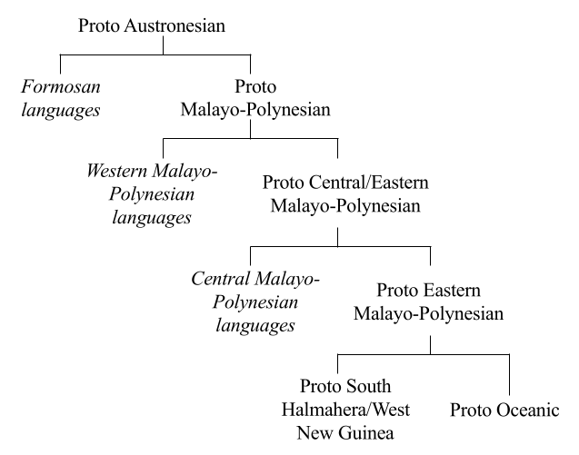

**Figure 1:** Schematic diagram showing higher-order subgroups of Austronesian languages

### 3.2. Subgrouping and reconstruction

#### 3.2.1. Subgrouping

Although the subgrouping of Austronesian languages, and hypotheses about which protolanguage was spoken where, remain in certain cases somewhat controversial, it is impossible to proceed without making some assumptions about these matters. Figures 1 and 2 are approximate renderings of our subgrouping assumptions. The upper part of the tree, shown in Figure 1, is due to Blust, originally presented in Blust (1977b) and repeated with additional supporting evidence in subsequent publications (Blust 1978a, 1982, 1983-84b, 1993, 2009a).[^5] The diagram of the lower (Oceanic) part of the tree in Figure 2 shows nine primary subgroups of Oceanic. Its rake-like structure indicates that no convincing body of shared innovations has been found to allow any of the nine subgroups to be combined into higher-order groupings. Sections 1.3.2.2, 1.3.2.3 and 1.3.2.4 offer some commentary on our subgrouping, and in §1.3.2.4 we explain how we handle the rake-like structure in making reconstructions.

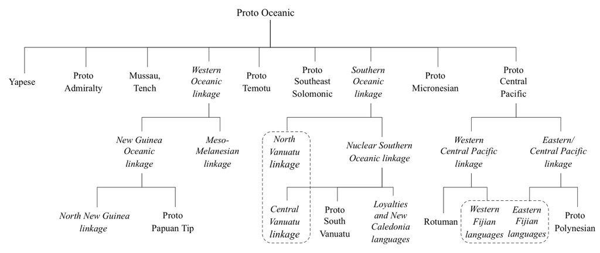

**Figure 2:** Schematic diagram showing the subgrouping of Oceanic Austronesian languages.

#### 3.2.2. Kinds of subgroup

In Figures 1 and 2 each node is either a single language,[^6] usually a reconstructed protolanguage, or, in italics, a group of languages.

Where a node is a protolanguage, its descendants form a proper subgroup (in the technical sense in which historical linguists use the term ‘subgroup’). A proper subgroup is identified by innovations shared by its member languages, i.e. it is ‘innovation-defined’ in the terminology of Pawley & Ross (1995). These innovations are assumed to have occurred just once in the subgroup’s protolanguage, i.e. the exclusively shared ancestor of its members. Thus languages of the large Oceanic subgroup of Austronesian share a set of innovations relative to the earlier Austronesian stages shown in Figure 1 (Dempwolff 1934).[^7] By inference these innovations occurred in their common ancestor, POc, and the claim that they are innovations is based on a comparison of reconstructed POc with reconstructed PMP. The innovations may be phonological (e.g. PMP *e, pronounced [ə], and PMP *aw both became POc *o), morphological (e.g. POc acquired a morphological distinction between three kinds of possessive relationship: food, drink and default), or lexical (e.g. PMP *limaw ‘citrus fruit’ was replaced by POc *molis).

Italics are used in Figures 1 and 2 to indicate a group of languages which is not a proper subgroup, i.e. has no identifiable *exclusively* shared parent. Thus *Formosan languages* in Figure 1 indicates a collection of languages descended (along with PMP) from PAn. They are spoken in Taiwan, but do not form a subgroup. There was no ‘Proto Formosan’, as Formosan languages and language groups are all descended directly from PAn.

Some of the italicised labels in Figures 1 and 2 include the term *linkage*. A linkage (an ‘innovation-linked group’ in the terminology of Pawley & Ross 1995) is a collection of usually quite closely related languages or dialects,[^8] speakers of which were in sufficient contact at one time or another during their history for innovations to pass from one language to the next, often resulting in a pattern such that the domains of various innovations overlap but are not coterminous.[^9] A number of Oceanic linkages have been recognised by scholars researching the history of the languages of Fiji (Geraghty 1983), of the Caroline Islands (Jackson 1983), of NW Melanesia (Ross 1988), of the SE Solomons (Lichtenberk 1988, 1994; Pawley 2011) and of Vanuatu (Tryon 1976, Clark 1985, Lynch 2000c, 2004b, François 2011a, 2014).[^10] A linkage may arise in at least three ways, but distinguishing between them is often impossible.

First, what would otherwise be a proper subgroup may happen to lack exclusively shared innovations, perhaps because the parent did not exist as a unit for long enough to undergo any innovations of its own.[^11]

Second, a linkage may consist of some but not all of the languages descended from a single parent. The Western Oceanic linkage reflects the innovations of POc, but no innovation is common to the whole of Western Oceanic (although the merger of POc *r and *R comes close). However, the languages of its three component linkages—North New Guinea, Papuan Tip and Meso-Melanesian—display complex patterns of overlapping innovations. The Western Oceanic linkage appears to be descended from the dialects of POc that were left behind in the Bismarck Archipelago after speakers of the languages ancestral to the other eight primary subgroups in Figure 2 had moved away to the north or east (Ross 2014, 2017). After these departures various innovations occurred. Each arose somewhere in the Western Oceanic dialect network and spread to neighbouring dialects without reaching every dialect in the network.

The third type of linkage is the result of contact among languages descended from more than one immediate parent, indicated in Figure 2 by a dashed line around the relevant groups of languages. An example is the Fijian linkage, which represents the partial resynthesis of the Fiji-based descendants of earlier Western Central Pacific and Eastern Central Pacific linkages after Rotuman and Polynesian had split off from them (Geraghty & Pawley 1981, Geraghty 1983, Pawley 1996c).[^12] Geraghty reconstructed the history of the Fijian linkage by painstaking analysis of innovations from at least two stages in its history. From the earlier period Western Fijian languages share innovations with Rotuman and Eastern Fijian with Polynesian. From a more recent period Western Fijian and Eastern Fijian languages share innovations with each other, reflecting their reintegration into a single linkage, within which the present Western/Eastern boundary has shifted relative to the (fuzzy) boundary of the earlier period.

For most of the linkages noted in Figures 1 and 2 this kind of analysis is not available. For example, Blust (1993) argues that CEMP was a linkage. But its history is far from clear. Does CEMP perhaps include some languages that share history with languages to their west and others that share history with those to their north? The North/Central Vanuatu linkage, long assumed to be some sort of genealogical unit, appears to reflect the partial reintegration of at east two dialect networks, North Vanuatu and Central Vanuatu, that probably had not diverged greatly from each other, but the details of this history are difficult to elucidate (Lynch 2000c).[^13]

The languages of a linkage have no identifiable exclusively shared parent.Yet we have found many instances in which a cognate set is limited to one of the linkages in Figures 1 and 2: CEMP, Western Oceanic, New Guinea Oceanic, Southern Oceanic or the reintegrated North and Central Vanuatu linkage. As with PEOc and PROc (§1.3.2.4), we think it is preferable to attribute these reconstructions to a hypothetical protolanguage rather than to a higher node in the tree. Hence there are reconstructions labelled PCEMP, PWOc and so on.

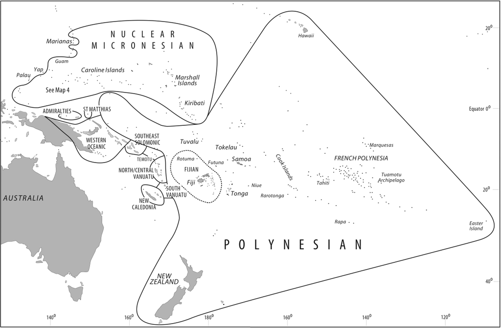

**Map 3:** Groups of Oceanic languages used in cognate sets

Again these apparent lexical innovations offer only the weakest evidence for the protolanguage to which they are attributed. In addition to the explanations of the kinds offered for PEOc and PROc etyma in §1.3.2.4 it is possible, for example, that an innovatory ‘PWOc’ etymon arose when the Western Oceanic dialect network was still close-knit, and spread from dialect to dialect before the network broke into the two networks ancestral to its present-day first-order subgroups.

#### 3.2.3. Further notes on subgroups

This section brings together brief notes on the subgroups in Figure 2 beyond those mentioned in the discussion in §1.3.2.2.

*Admiralty* is a proper subgroup Ross (1988: ch.9).

*Western Oceanic* consists of the North New Guinea linkage (NNG), Papuan Tip family (PT), Meso-Melanesian linkage (MM) and the Sarmi/Jayapura (SJ) group (see Map 4). The last-named may belong to the NNG linkage, but this is uncertain Ross (1996b). It is not shown in Figure 2 and its languages do not play a crucial role in reconstruction. It is possible that the NNG and PT groups form a super-group, the New Guinea Oceanic linkage, and so etyma reflected only in NNG and PT languages are attributed to a putative Proto New Guinea Oceanic (Milke 1958, Pawley 1978), and etyma reflected in either NNG or PT (or both) and in MM are labelled PWOc.

*SE Solomonic* was established as a proper subgroup by Pawley (1972:98–110). Further support was provided by Levy (1979, 1980, n.d.), Tryon & Hackman (1983) and Lichtenberk (1988). Lichtenberk (1994b) and Pawley (2011) look at the internal structure of SE Solomonic.

*Temotu* comprises the languages of the Reef Islands, Santa Cruz, Utupua and Vanikoro, located 400 km east of the main Solomons archipelago and to the north of Vanuatu (Map 3). Its identity as a proper subgroup of Oceanic was established by Ross & Næss (2007) and further supported by Næss & Boerger (2008).

The *Southern Oceanic* linkage as proposed by Lynch (1999, 2000c, 2001d, 2004b) is characterised by complex overlapping innovations, but by none that are reflected in all its member languages and would qualify it as a proper subgroup (see discussion in Lynch et al. 2002:112–114).[^14]

*Micronesian* is a proper subgroup (Jackson 1983, 1986, Bender et al. 2003).

*Central Pacific* is a proper subgroup, but one defined by only a handful of shared innovations, indicating that the period of unity was short (Geraghty 1996). The high-order subgrouping of Central Pacific is due to Geraghty (1983), except for the position of Rotuman, due to Pawley (1996b). Within Central Pacific is another long recognised proper subgroup, Polynesian, for which Pawley (1996a) lists diagnostic innovations.

#### 3.2.4. Criteria for reconstruction

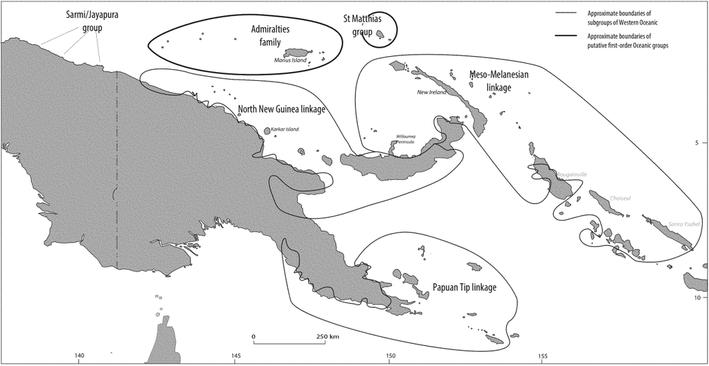

**Map 4:** Oceanic language groups in northwest Melanesia: The Admiralties and St. Matthias groups and the subgroups of Western Oceanic

The strength of a lexical reconstruction rests crucially on the distribution of the supporting cognate set across subgroups. The distribution of cognate forms and agreements in their meanings is much more important than the number of cognates. It is enough to make a secure reconstruction if a cognate set occurs in just two languages in a family, with agreement in meaning, provided that the two languages belong to different primary subgroups and provided that there is no reason to suspect that the resemblances are due to borrowing or chance. The PMP term *apij ‘twins’ is reflected in several western Malayo-Polynesian languages (e.g. Batak *apid* ‘twins, double (fused) banana’) but only a single Oceanic reflex is known, namely Roviana *avisi* ‘twins of the same sex’. Because Roviana belongs to a different first-order branch of Malayo-Polynesian from the western Malayo-Polynesian witnesses and because there is virtually no chance that the agreement is due to borrowing or chance similarity, this distribution is enough to justify the reconstruction of PMP *apij, POc *apic ‘twins’.

The rake-like form of Figure 2 almost certainly reflects the very rapid settlement of Oceania out of the Bismarcks,[^15] but it confronts us with a methodological question. If we follow the rubric that we make a reconstruction if a cognate set occurs in languages of just two primary subgroups, then reflexes of an etymon in, say, a SE Solomonic language and a Micronesian language would be sufficient evidence for a POc reconstruction and the absence of reflexes in Admiralty and Western Oceanic would be irrelevant. Given what we know about the location of the POc homeland (in the Bismarcks; vol.2, ch.2) and the early eastward spread of Oceanic speakers, this is too loose a criterion. Instead, we assume two hypothetical nodes not shown in the tree in Figure 2.[^16] These are

- Remote Oceanic, comprising Southern Oceanic, Micronesian and Central Pacific;
- Eastern Oceanic, comprising SE Solomonic and Remote Oceanic.[^17]

If a cognate set occurs in two or all three of the groups in Remote Oceanic, the reconstruction is attributed to PROc (PROc). If a cognate set occurs in one or more of the groups in Remote Oceanic and in SE Solomonic, it is attributed to Proto Eastern Oceanic (PEOc). In this way we acknowledge that such reconstructions may represent an innovation that postdates the spread of the early Oceanic speech community. There are enough PROc and PEOc reconstructions to suggest that such lexical innovations indeed occurred. This in turn provides evidence for Remote Oceanic and Eastern Oceanic subgroups, but evidence that is too weak to be relied on, for at least two reasons. First, it is quite possible that some of our PROc and PEOc reconstructions will be promoted to POc as more Admiralty and Western Oceanic data become available. Second, it is reasonable to assume that some of our PROc and PEOc etyma are of POc antiquity but happen to have been lost in Proto Admiralty and Proto Western Oceanic. Without supporting phonological or morphological evidence we are unwilling to treat PROc or PEOc as anything other than convenient hypothetical groups which allow us to retain conservative criteria for a POc reconstruction.